# DATA 621 Homework #3

```r
df <- read.csv('data/crime-training-data_modified.csv')
evaluation <- read.csv("data/crime-evaluation-data_modified.csv")
```

## Data Exploration

### Are There Missing Values?

First we look at the data to see if any variables have missing data:

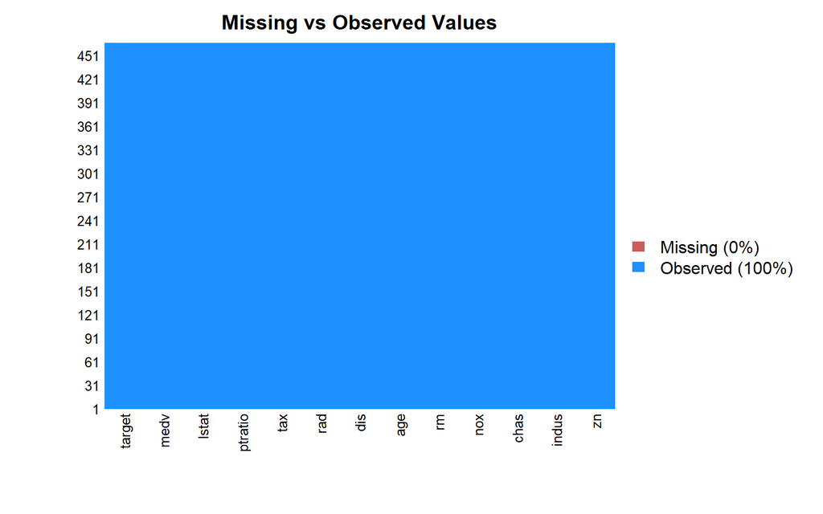

```r
missmap(df, main = "Missing vs Observed Values")
```

It looks like we have a complete data set. No need to impute values.

### Splitting the Data

Next, we look to split our data between a training set (`train`) and a test data set (`test`). We’ll use a 70-30 split between train and test, respectively.

```r
set.seed(42)
train_index <- createDataPartition(df$target, p = .7, list = FALSE, times = 1)
train <- df[train_index,]
test <- df[-train_index,]
```

### Exploratory Data Analysis

Now, let’s look at our training data. By looking at a correlation matrix, we can see which variables may be too correlated to be included together in a model as predictor variables. This will help us later during the model selection process.

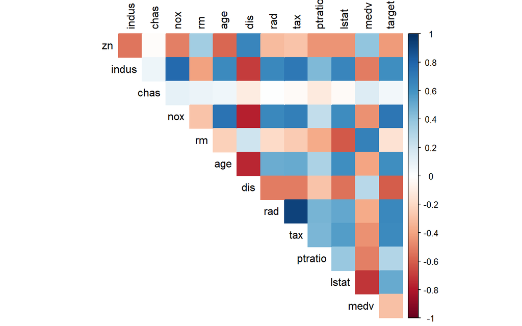

```r
train %>%
  cor(.) %>%
  corrplot(., method = "color", type = "upper", tl.col = "black", diag = FALSE)
```

Next we will look at each potential predictor and how it is distributed across the target variable.

The following plots show how predictors are distributed between a positive target variable (areas with crime rates higher than the median, i.e. blue) and a negative target variable (areas with crime rates below the median, i.e. red). What we are looking for is variables that show way to split data into two groups.

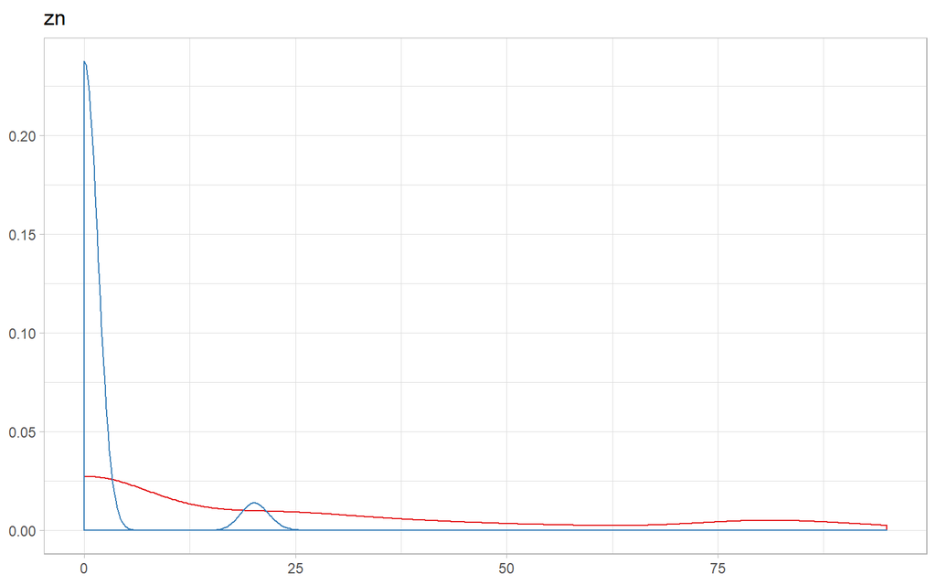

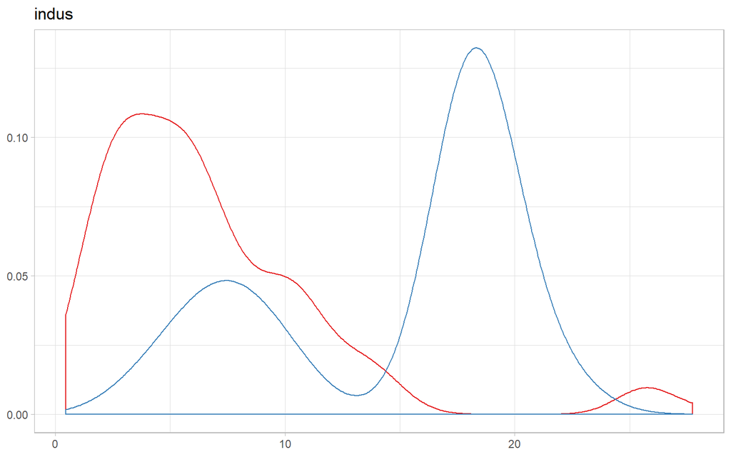

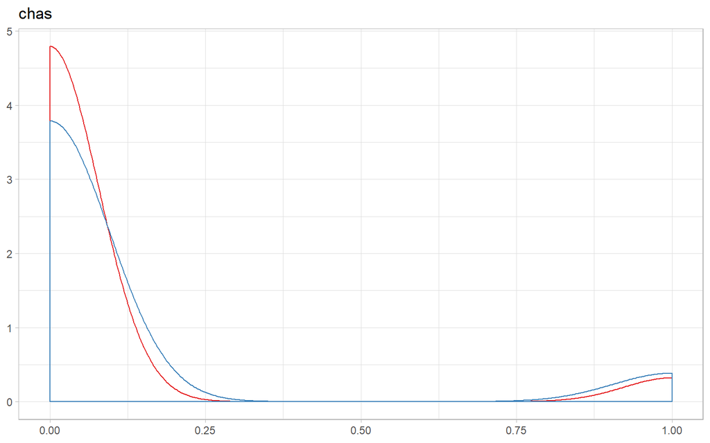

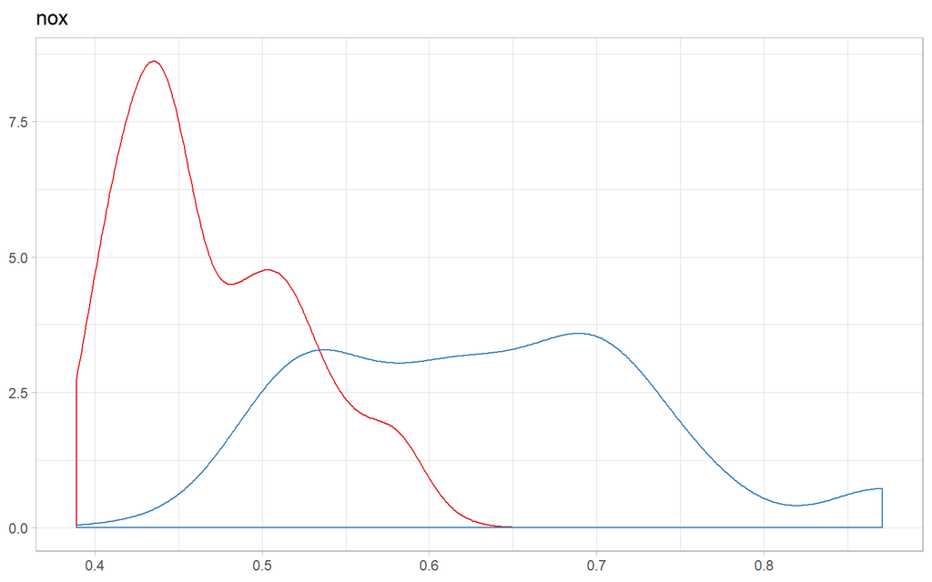

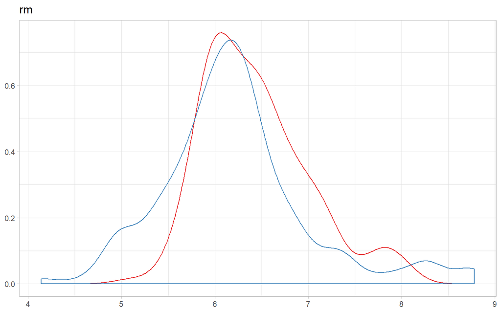

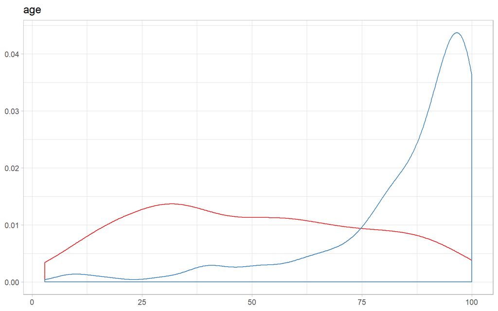

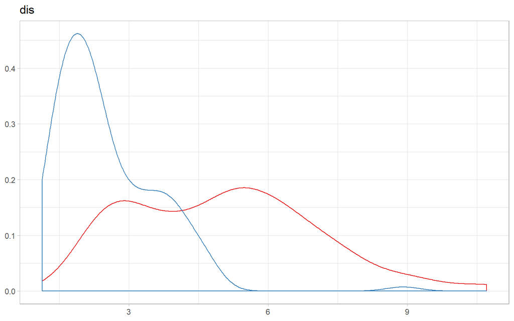

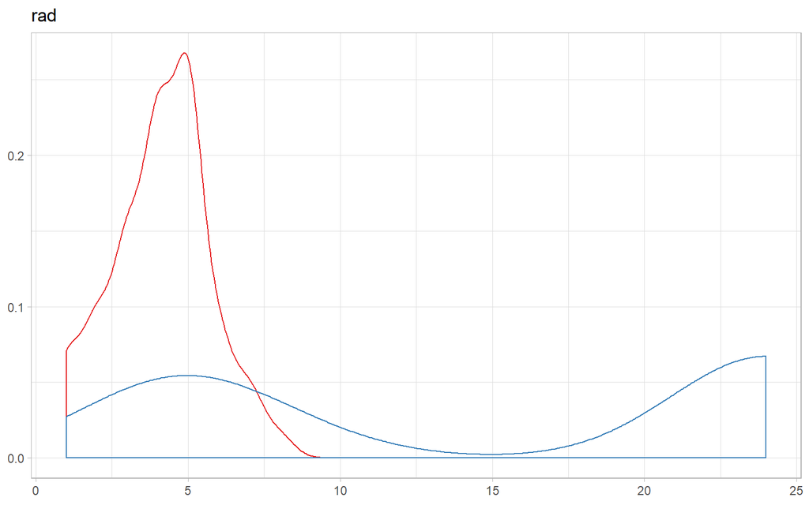

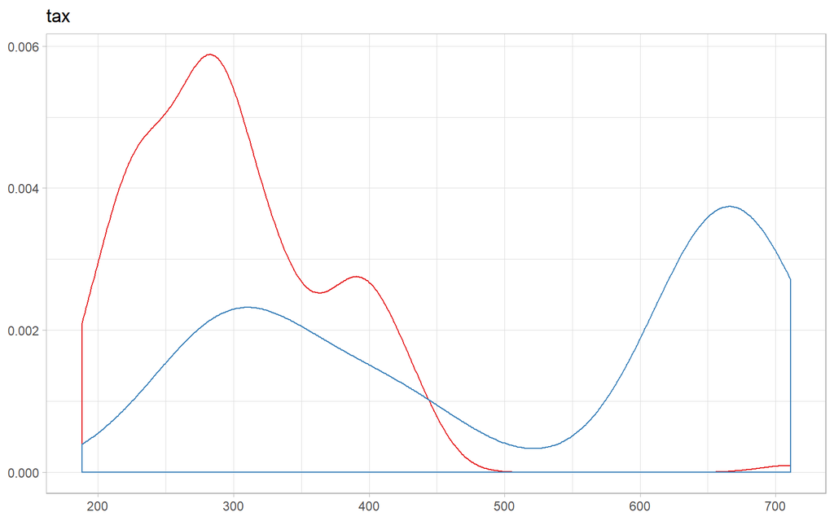

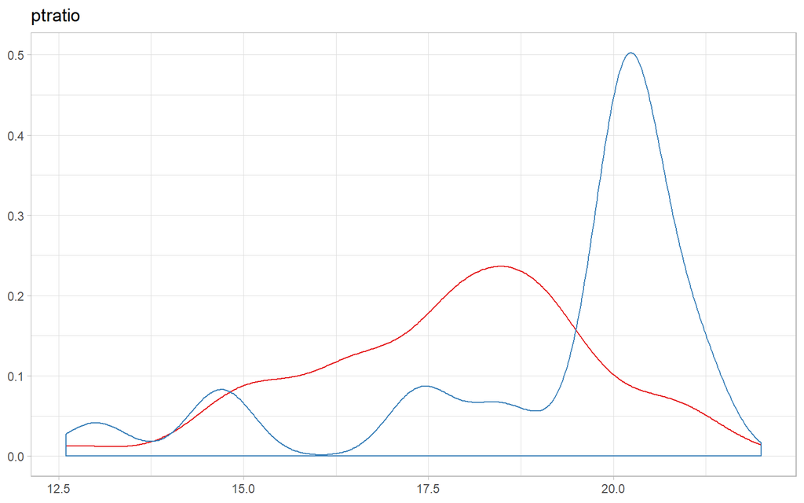

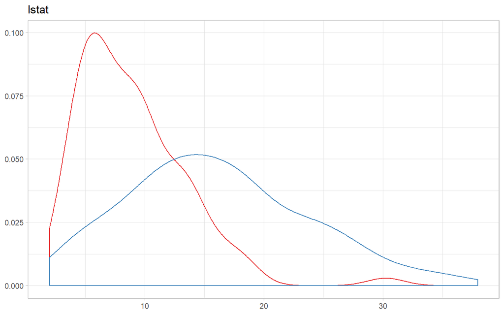

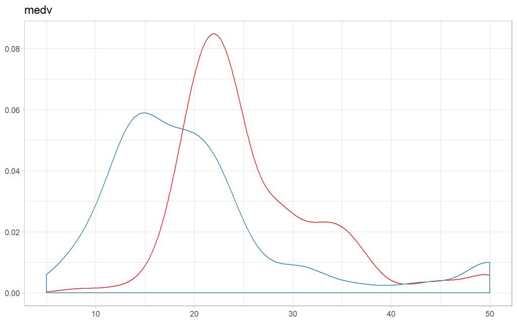

```r
for (var in names(train)){
  if(var != "target"){
    plot_df <- train
    plot_df$x <- plot_df[,var]
    p <- ggplot(plot_df, aes(x, color = factor(target))) +
      geom_density() +
      theme_light() +
      ggtitle(var) +
      scale_color_brewer(palette = "Set1") +
      theme(legend.position = "none",
            axis.title.y = element_blank(),
            axis.title.x = element_blank())
    print(p)
  }
}
```

Looking at the plots above, the `nox` variable seems to be the best variable to divide the data into the two groups.

## Basic Model Building

We start by applying occam’s razor and create a baseline model that only has one predictor. Any model we build beyond that will have to outperform this simplest model.

```r
baseline <- glm(target ~ nox, family = binomial(link = "logit"), train)
summary(baseline)
```

```
Call:
glm(formula = target ~ nox, family = binomial(link = "logit"),
    data = train)

Deviance Residuals:
    Min       1Q   Median       3Q      Max
-2.1163  -0.4050  -0.1814   0.2717   2.5754

Coefficients:
            Estimate Std. Error z value Pr(>|z|)
(Intercept)  -16.370      1.823  -8.981   <2e-16 ***
nox           30.372      3.444   8.818   <2e-16 ***
---
Signif. codes:  0 '***' 0.001 '**' 0.01 '*' 0.05 '.' 0.1 ' ' 1

(Dispersion parameter for binomial family taken to be 1)

    Null deviance: 451.70  on 326  degrees of freedom
Residual deviance: 205.67  on 325  degrees of freedom
AIC: 209.67

Number of Fisher Scoring iterations: 6
```

```r
test$baseline <- ifelse(predict.glm(baseline, test,"response") >= 0.5,1,0)
cm <- confusionMatrix(factor(test$baseline), factor(test$target),"1")
results <- tibble(model = "baseline",predictors = 1,F1 = cm$byClass[7],
                  deviance=baseline$deviance,
                  r2 = 1 - baseline$deviance/baseline$null.deviance,
                  aic=baseline$aic)
cm
```

```
Confusion Matrix and Statistics

          Reference
Prediction  0  1
         0 50 11
         1 12 66

               Accuracy : 0.8345
                 95% CI : (0.7621, 0.8921)
    No Information Rate : 0.554
    P-Value [Acc > NIR] : 2.178e-12

                  Kappa : 0.6646

 Mcnemar's Test P-Value : 1

            Sensitivity : 0.8571
            Specificity : 0.8065
         Pos Pred Value : 0.8462
         Neg Pred Value : 0.8197
             Prevalence : 0.5540
         Detection Rate : 0.4748
   Detection Prevalence : 0.5612
      Balanced Accuracy : 0.8318

       'Positive' Class : 1
```

Our baseline model is ok with an F1 score of 0.8516129.

Next we try adding every other variable, to build a full model. From here we can work backwards and eliminate non-significant predictors:

```r
fullmodel <- glm(target ~ ., family = binomial(link = "logit"), train)
summary(fullmodel)
```

```
Call:
glm(formula = target ~ ., family = binomial(link = "logit"),
    data = train)

Deviance Residuals:
    Min       1Q   Median       3Q      Max
-2.1095  -0.1955  -0.0025   0.0010   3.4349

Coefficients:
              Estimate Std. Error z value Pr(>|z|)
(Intercept) -45.183151   8.234576  -5.487 4.09e-08 ***
zn           -0.075536   0.044071  -1.714 0.086539 .
indus        -0.091581   0.057306  -1.598 0.110020
chas          0.686033   0.878327   0.781 0.434763
nox          52.841701   9.811850   5.385 7.22e-08 ***
rm           -0.060835   0.895649  -0.068 0.945847
age           0.014775   0.014866   0.994 0.320276
dis           0.748904   0.277029   2.703 0.006865 **
rad           0.693492   0.192573   3.601 0.000317 ***
tax          -0.004634   0.003734  -1.241 0.214522
ptratio       0.376793   0.162243   2.322 0.020211 *
lstat         0.146590   0.065105   2.252 0.024349 *
medv          0.159840   0.086270   1.853 0.063912 .
---
Signif. codes:  0 '***' 0.001 '**' 0.01 '*' 0.05 '.' 0.1 ' ' 1

(Dispersion parameter for binomial family taken to be 1)

    Null deviance: 451.70  on 326  degrees of freedom
Residual deviance: 136.79  on 314  degrees of freedom
AIC: 162.79

Number of Fisher Scoring iterations: 9
```

```r
test$fullmodel <- ifelse(predict.glm(fullmodel, test,"response") < 0.5, 0, 1)
cm <- confusionMatrix(factor(test$fullmodel), factor(test$target),"1")
results <- rbind(results,tibble(model = "fullmodel",
                                predictors = 12,F1 = cm$byClass[7],
                                deviance=fullmodel$deviance,
                                r2 = 1-fullmodel$deviance/fullmodel$null.deviance,
                                aic=fullmodel$aic))
cm
```

```
Confusion Matrix and Statistics

          Reference
Prediction  0  1
         0 55  6
         1  7 71

               Accuracy : 0.9065
                 95% CI : (0.8454, 0.9493)
    No Information Rate : 0.554
    P-Value [Acc > NIR] : <2e-16

                  Kappa : 0.8104

 Mcnemar's Test P-Value : 1

            Sensitivity : 0.9221
            Specificity : 0.8871
         Pos Pred Value : 0.9103
         Neg Pred Value : 0.9016
             Prevalence : 0.5540
         Detection Rate : 0.5108
   Detection Prevalence : 0.5612
      Balanced Accuracy : 0.9046

       'Positive' Class : 1
```

The full model has an F1 score is 0.916129, which is a bit higher than before. However, many variables do not seem to be significant.

After some backward elimination of non-significant predictor variables, we arrive at the following model:

```r
model1 <- glm(target ~ . -tax -rm -chas - age -zn -indus,
              family = binomial(link = "logit"),
              train)
summary(model1)
```

```
Call:
glm(formula = target ~ . - tax - rm - chas - age - zn - indus,
    family = binomial(link = "logit"), data = train)

Deviance Residuals:
     Min        1Q    Median        3Q       Max
-2.25157  -0.28019  -0.06287   0.00092   2.93960

Coefficients:
             Estimate Std. Error z value Pr(>|z|)
(Intercept) -40.36177    7.32297  -5.512 3.55e-08 ***
nox          43.62710    7.91385   5.513 3.53e-08 ***
dis           0.43922    0.19736   2.225  0.02605 *
rad           0.64560    0.14500   4.453 8.49e-06 ***
ptratio       0.38903    0.13439   2.895  0.00379 **
lstat         0.13126    0.05636   2.329  0.01986 *
medv          0.14156    0.04686   3.021  0.00252 **
---
Signif. codes:  0 '***' 0.001 '**' 0.01 '*' 0.05 '.' 0.1 ' ' 1

(Dispersion parameter for binomial family taken to be 1)

    Null deviance: 451.70  on 326  degrees of freedom
Residual deviance: 149.16  on 320  degrees of freedom
AIC: 163.16

Number of Fisher Scoring iterations: 9
```

```r
test$model1 <- ifelse(predict.glm(model1, test,"response") < 0.5, 0, 1)
cm <- confusionMatrix(factor(test$model1), factor(test$target),"1")
results <- rbind(results,tibble(model = "model1",
                                predictors = 6,F1 = cm$byClass[7],
                                deviance=model1$deviance,
                                r2 = 1-model1$deviance/model1$null.deviance,
                                aic=model1$aic))
cm
```

```
Confusion Matrix and Statistics

          Reference
Prediction  0  1
         0 51  5
         1 11 72

               Accuracy : 0.8849
                 95% CI : (0.8198, 0.9328)
    No Information Rate : 0.554
    P-Value [Acc > NIR] : <2e-16

                  Kappa : 0.7649

 Mcnemar's Test P-Value : 0.2113

            Sensitivity : 0.9351
            Specificity : 0.8226
         Pos Pred Value : 0.8675
         Neg Pred Value : 0.9107
             Prevalence : 0.5540
         Detection Rate : 0.5180
   Detection Prevalence : 0.5971
      Balanced Accuracy : 0.8788

       'Positive' Class : 1
```

## Alternative Models

### Feature Engineering

In this portion below we explored using the difference between the class distributions as a feature itself. So instead of the raw feature itself the we created density features that are essientially the differences in probability of the positve and negative classes at that certain point for the feature.

```r
library(fuzzyjoin)
density_diff <- function(data,eval_data,var,target,new_column){
  data[[paste0(var,"temp")]] <- data[[var]]
  eval_data[[paste0(var,"temp")]] <- eval_data[[var]]

  #standardize variable between 0 and 1
  data[[var]] <- (data[[var]] - min(data[[var]]))/(max(data[[var]]) - min(data[[var]]))
  eval_data[[var]] <- (eval_data[[var]] - min(eval_data[[var]]))/(max(eval_data[[var]]) - min(eval_data[[var]]))

  ## Calculate density estimates
  g1 <- ggplot(data, aes(x=data[[var]], group=target, colour=target)) +
    geom_density(data = data) + xlim(min(data[[var]]), max(data[[var]]))
  gg1 <- ggplot_build(g1)
  # construct the dataset
  x <- gg1$data[[1]]$x[gg1$data[[1]]$group == 1]
  y1 <- gg1$data[[1]]$y[gg1$data[[1]]$group == 1]
  y2 <- gg1$data[[1]]$y[gg1$data[[1]]$group == 2]
  df2 <- data.frame(x = x, ymin = pmin(y1, y2), ymax = pmax(y1, y2), side=(y1<y2), ydiff = y2-y1)
  ##creating the second graph object
  g3 <- ggplot(df2) +
    geom_line(aes(x = x, y = ydiff, colour = side)) +
    geom_area(aes(x = x, y = ydiff, fill = side, alpha = 0.4)) +
    guides(alpha = FALSE, fill = FALSE)

  data$join <- data[[var]]
  df2$join <- df2$x
  temp <- difference_left_join(data,df2, by="join", max_dist =.001)
  means <- aggregate(ydiff ~ temp$join.x, temp, mean)

  colnames(means) <- c("std_var","density_diff")

  new_data <- merge(means,data, by.x ="std_var", by.y =var)
  new_data$std_var <- NULL
  new_data$join <- NULL
  new_data[new_column] <- new_data$density_diff
  new_data$density_diff <- NULL
  ###################same thing with eval data ############################
  eval_data$join <- eval_data[[var]]
  df2$join <- df2$x
  temp <- difference_left_join(eval_data,df2, by="join", max_dist =.001)
  means <- aggregate(ydiff ~ temp$join.x, temp, mean)

  ##new stuff
  colnames(means) <- c("std_var","density_diff")
  #data["key"] <- (var - min(var))/(max(var) - min(var))

  eval_data2 <- merge(means,eval_data, by.x ="std_var", by.y =var)
  eval_data2$std_var <- NULL
  eval_data2$join <- NULL
  eval_data2[new_column] <- eval_data2$density_diff
  eval_data2$density_diff <- NULL

  eval_data2[[var]] <- eval_data2[[paste0(var,"temp")]]
  eval_data2[[paste0(var,"temp")]] <- NULL

  new_data[[var]] <- new_data[[paste0(var,"temp")]]
  new_data[[paste0(var,"temp")]] <- NULL

  mylist <- list(g1,g3,new_data,eval_data2)
  names(mylist)<- c("dist","dist_diff","new_data_training","new_data_eval")
  return(mylist)
}
```

### Creating Some New Variables

```r
str(train)
```

```
'data.frame':   327 obs. of  13 variables:
 $ zn     : num  0 0 0 30 0 0 80 22 0 22 ...
 $ indus  : num  19.58 19.58 18.1 4.93 2.46 ...
 $ chas   : int  0 1 0 0 0 0 0 0 0 0 ...
 $ nox    : num  0.605 0.871 0.74 0.428 0.488 0.52 0.392 0.431 0.437 0.431 ...
 $ rm     : num  7.93 5.4 6.49 6.39 7.16 ...
 $ age    : num  96.2 100 100 7.8 92.2 71.3 19.1 8.9 45 8.4 ...
 $ dis    : num  2.05 1.32 1.98 7.04 2.7 ...
 $ rad    : int  5 5 24 6 3 5 1 7 5 7 ...
 $ tax    : int  403 403 666 300 193 384 315 330 398 330 ...
 $ ptratio: num  14.7 14.7 20.2 16.6 17.8 20.9 16.4 19.1 18.7 19.1 ...
 $ lstat  : num  3.7 26.82 18.85 5.19 4.82 ...
 $ medv   : num  50 13.4 15.4 23.7 37.9 26.5 20.9 24.8 21.4 42.8 ...
 $ target : int  1 1 1 0 0 0 0 0 0 1 ...
```

```r
str(test)
```

```
'data.frame':   139 obs. of  16 variables:
 $ zn       : num  0 0 0 0 0 100 0 0 0 0 ...
 $ indus    : num  18.1 18.1 5.19 18.1 2.46 1.32 18.1 3.24 6.2 2.89 ...
 $ chas     : int  0 0 0 0 0 0 0 0 1 0 ...
 $ nox      : num  0.693 0.693 0.515 0.532 0.488 0.411 0.679 0.46 0.507 0.445 ...
 $ rm       : num  5.45 4.52 6.32 7.06 6.15 ...
 $ age      : num  100 100 38.1 77 68.8 40.5 95.4 32.2 66.5 62.5 ...
 $ dis      : num  1.49 1.66 6.46 3.41 3.28 ...
 $ rad      : int  24 24 5 24 3 5 24 4 8 2 ...
 $ tax      : int  666 666 224 666 193 256 666 430 307 276 ...
 $ ptratio  : num  20.2 20.2 20.2 20.2 17.8 15.1 20.2 16.9 17.4 18 ...
 $ lstat    : num  30.59 36.98 5.68 7.01 13.15 ...
 $ medv     : num  5 7 22.2 25 29.6 31.6 8.3 19.8 29 33.2 ...
 $ target   : int  1 1 0 1 0 0 1 0 1 0 ...
 $ baseline : num  1 1 0 0 0 0 1 0 0 0 ...
 $ fullmodel: num  1 1 1 1 0 0 1 0 1 0 ...
 $ model1   : num  1 1 0 1 0 0 1 0 1 0 ...
```

```r
## try it out
train <- density_diff(train,test,"nox",train$target,"nox_density")$new_data_training
train <- density_diff(train,test,"age",train$target,"age_density")$new_data_training
train <- density_diff(train,test,"indus",train$target,"indus_density")$new_data_training
train <- density_diff(train,test,"dis",train$target,"dis_density")$new_data_training
train <- density_diff(train,test,"rad",train$target,"rad_density")$new_data_training
train <- density_diff(train,test,"tax",train$target,"tax_density")$new_data_training
train <- density_diff(train,test,"ptratio",train$target,"ptratio_density")$new_data_training
train <- density_diff(train,test,"lstat",train$target,"lstat_density")$new_data_training
train <- density_diff(train,test,"medv",train$target,"medv_density")$new_data_training

test<- density_diff(train,test,"nox",train$target,"nox_density")$new_data_eval
test<- density_diff(train,test,"age",train$target,"age_density")$new_data_eval
test<- density_diff(train,test,"indus",train$target,"indus_density")$new_data_eval
test<- density_diff(train,test,"dis",train$target,"dis_density")$new_data_eval
test<- density_diff(train,test,"rad",train$target,"rad_density")$new_data_eval
test<- density_diff(train,test,"tax",train$target,"tax_density")$new_data_eval
test<- density_diff(train,test,"ptratio",train$target,"ptratio_density")$new_data_eval
test<- density_diff(train,test,"lstat",train$target,"lstat_density")$new_data_eval
test<- density_diff(train,test,"medv",train$target,"medv_density")$new_data_eval

str(train)
```

```
'data.frame':   327 obs. of  22 variables:
 $ zn             : num  0 0 0 0 0 0 0 0 0 0 ...
 $ chas           : int  0 0 0 0 0 0 0 0 0 0 ...
 $ rm             : num  5.68 5.99 5.28 5 6.78 ...
 $ target         : int  1 1 1 1 1 0 1 1 1 1 ...
 $ nox_density    : num  1.73 1.73 1.7 1.7 1.71 ...
 $ nox            : num  0.693 0.693 0.7 0.7 0.679 0.609 0.718 0.693 0.74 0.679 ...
 $ age_density    : num  3.15 3.15 3.65 2.04 2.41 ...
 $ age            : num  100 100 98.1 89.5 90.8 98 76.5 85.4 100 95.6 ...
 $ indus_density  : num  3.58 3.58 3.58 3.58 3.58 ...
 $ indus          : num  18.1 18.1 18.1 18.1 18.1 ...
 $ dis_density    : num  3.02 3.47 3.02 3.31 3.64 ...
 $ dis            : num  1.43 1.59 1.43 1.52 1.82 ...
 $ rad_density    : num  1.54 1.54 1.54 1.54 1.54 ...
 $ rad            : int  24 24 24 24 24 4 24 24 24 24 ...
 $ tax_density    : num  1.95 1.95 1.95 1.95 1.95 ...
 $ tax            : int  666 666 666 666 666 711 666 666 666 666 ...
 $ ptratio_density: num  3.87 3.87 3.87 3.87 3.87 ...
 $ ptratio        : num  20.2 20.2 20.2 20.2 20.2 20.1 20.2 20.2 20.2 20.2 ...
 $ lstat_density  : num  1.013 0.723 0.248 0.222 0.822 ...
 $ lstat          : num  23 26.8 30.8 32 25.8 ...
 $ medv_density   : num  0.258 0.325 0.546 0.576 0.591 ...
 $ medv           : num  5 5.6 7.2 7.4 7.5 8.1 8.4 8.5 8.7 9.5 ...
```

```r
str(test)
```

```
'data.frame':   139 obs. of  25 variables:
 $ zn             : num  0 0 0 0 0 0 0 0 0 0 ...
 $ chas           : int  0 0 0 0 0 0 0 0 0 0 ...
 $ rm             : num  5.45 5.85 5.41 4.52 6.43 ...
 $ target         : int  1 1 0 1 1 1 1 1 1 1 ...
 $ baseline       : num  1 1 1 1 1 1 1 1 1 1 ...
 $ fullmodel      : num  1 1 0 1 1 1 1 1 1 1 ...
 $ model1         : num  1 1 1 1 1 1 1 1 1 1 ...
 $ nox_density    : num  1.73 1.73 1.2 1.73 1.7 ...
 $ nox            : num  0.693 0.693 0.609 0.693 0.679 0.693 0.679 0.693 0.693 0.7 ...
 $ age_density    : num  3.15 0.24 3.62 3.15 3.15 ...
 $ age            : num  100 77.8 98.3 100 100 100 95.4 96 98.9 91.2 ...
 $ indus_density  : num  3.47 3.47 -0.11 3.47 3.47 ...
 $ indus          : num  18.1 18.1 27.7 18.1 18.1 ...
 $ dis_density    : num  2.96 2.96 3.55 3.36 3.63 ...
 $ dis            : num  1.49 1.5 1.76 1.66 1.83 ...
 $ rad_density    : num  1.54 1.54 -4.35 1.54 1.54 ...
 $ rad            : int  24 24 4 24 24 24 24 24 24 24 ...
 $ tax_density    : num  1.95 1.95 1.37 1.95 1.95 ...
 $ tax            : int  666 666 711 666 666 666 666 666 666 666 ...
 $ ptratio_density: num  3.73 3.73 3.31 3.73 3.73 ...
 $ ptratio        : num  20.2 20.2 20.1 20.2 20.2 20.2 20.2 20.2 20.2 20.2 ...
 $ lstat_density  : num  0.2284 0.2481 0.9091 0.0852 0.3155 ...
 $ lstat          : num  30.6 30 24 37 29.1 ...
 $ medv_density   : num  0.258 0.414 0.517 0.517 0.546 ...
 $ medv           : num  5 6.3 7 7 7.2 7.2 8.3 8.3 8.5 8.8 ...
```

### Example of the new meta feature

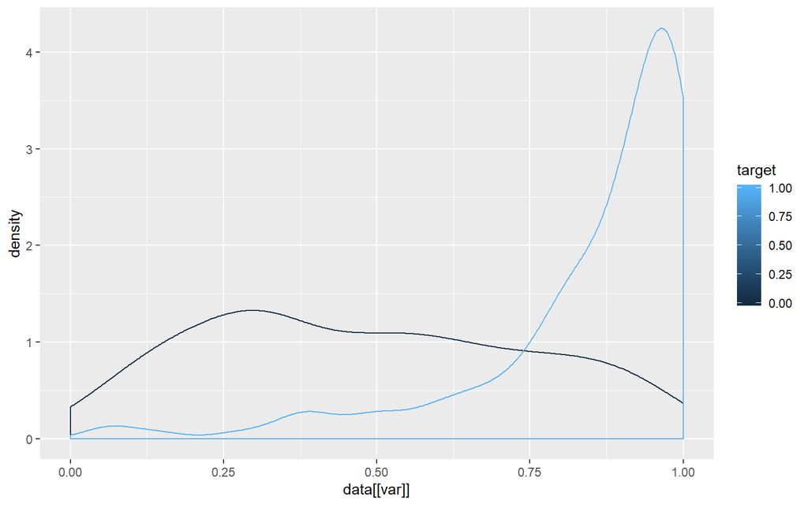

```r
density_diff(train,test,"age",train$target,"age_density")$dist
```

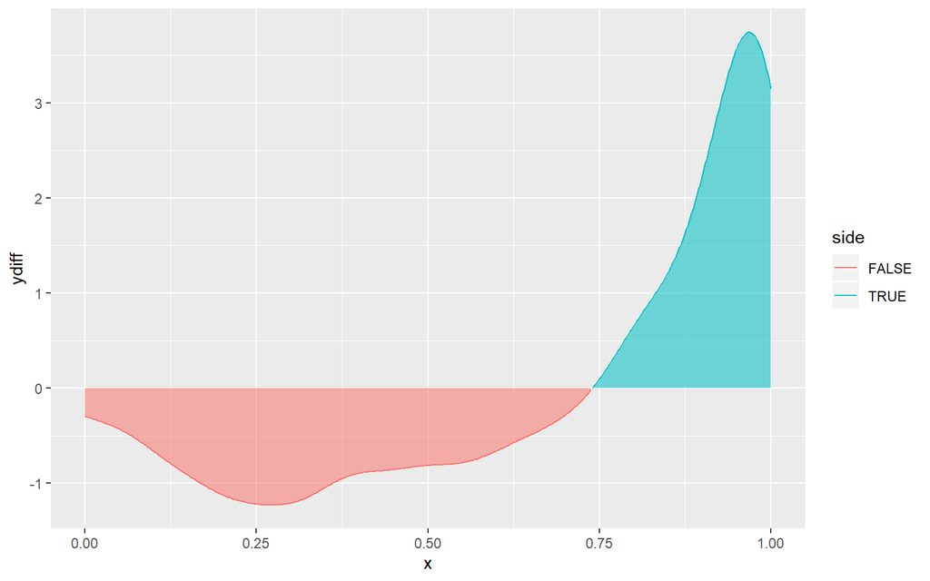

```r
density_diff(train,test,"age",train$target,"age_density")$dist_diff
```

With our new density variables, we can run another model:

```r
density_models <- glm(target ~ nox_density +indus_density+age_density+dis_density+rad_density+tax_density+ptratio_density+lstat_density+medv_density, family = binomial(link = "logit"), train)
summary(density_models)
```

```
Call:
glm(formula = target ~ nox_density + indus_density + age_density +
    dis_density + rad_density + tax_density + ptratio_density +
    lstat_density + medv_density, family = binomial(link = "logit"),
    data = train)

Deviance Residuals:
     Min        1Q    Median        3Q       Max
-2.96836  -0.31245  -0.06225   0.20194   3.01402

Coefficients:
                Estimate Std. Error z value Pr(>|z|)
(Intercept)       0.8093     0.5320   1.521 0.128210
nox_density       1.1492     0.2600   4.420 9.86e-06 ***
indus_density     1.0706     0.2488   4.302 1.69e-05 ***
age_density       0.1219     0.1698   0.718 0.472916
dis_density      -0.1849     0.2138  -0.865 0.387284
rad_density       0.4141     0.1226   3.379 0.000727 ***
tax_density      -1.2582     0.4408  -2.854 0.004314 **
ptratio_density   0.1550     0.1524   1.017 0.309139
lstat_density    -0.2456     0.2055  -1.195 0.231963
medv_density      0.5417     0.2062   2.628 0.008596 **
---
Signif. codes:  0 '***' 0.001 '**' 0.01 '*' 0.05 '.' 0.1 ' ' 1

(Dispersion parameter for binomial family taken to be 1)

    Null deviance: 451.70  on 326  degrees of freedom
Residual deviance: 164.12  on 317  degrees of freedom
AIC: 184.12

Number of Fisher Scoring iterations: 7
```

```r
test$density_models <- ifelse(predict(density_models, test) < 0.5, 0, 1)
test$density_models_yhat <- predict(density_models, test)
cm <- confusionMatrix(factor(test$density_models), factor(test$target))
results <- rbind(results,tibble(model = "density models",
                                predictors = 9,
                                F1 = cm$byClass[7],
                                deviance = density_models$deviance,
                                r2 = 1 - density_models$deviance / density_models$null.deviance,
                                aic = density_models$aic))
cm
```

```
Confusion Matrix and Statistics

          Reference
Prediction  0  1
         0 58 12
         1  4 65

               Accuracy : 0.8849
                 95% CI : (0.8198, 0.9328)
    No Information Rate : 0.554
    P-Value [Acc > NIR] : < 2e-16

                  Kappa : 0.77

 Mcnemar's Test P-Value : 0.08012

            Sensitivity : 0.9355
            Specificity : 0.8442
         Pos Pred Value : 0.8286
         Neg Pred Value : 0.9420
             Prevalence : 0.4460
         Detection Rate : 0.4173
   Detection Prevalence : 0.5036
      Balanced Accuracy : 0.8898

       'Positive' Class : 0
```

## Model Selection

Since the assignment mentions that the purpose is prediction, we will prefer F1 score as our measure of model success.

```r
kable(results)
```

| model | predictors | F1 | deviance | r2 | aic |
| --- | --- | --- | --- | --- | --- |
| baseline | 1 | 0.8516129 | 205.6730 | 0.5446683 | 209.6730 |
| fullmodel | 12 | 0.9161290 | 136.7893 | 0.6971673 | 162.7893 |
| model1 | 6 | 0.9000000 | 149.1603 | 0.6697795 | 163.1603 |
| density models | 9 | 0.8787879 | 164.1193 | 0.6366623 | 184.1193 |

### pROC Output

ROC curves can give us another look at which model might be better suited for prediction.

#### Baseline

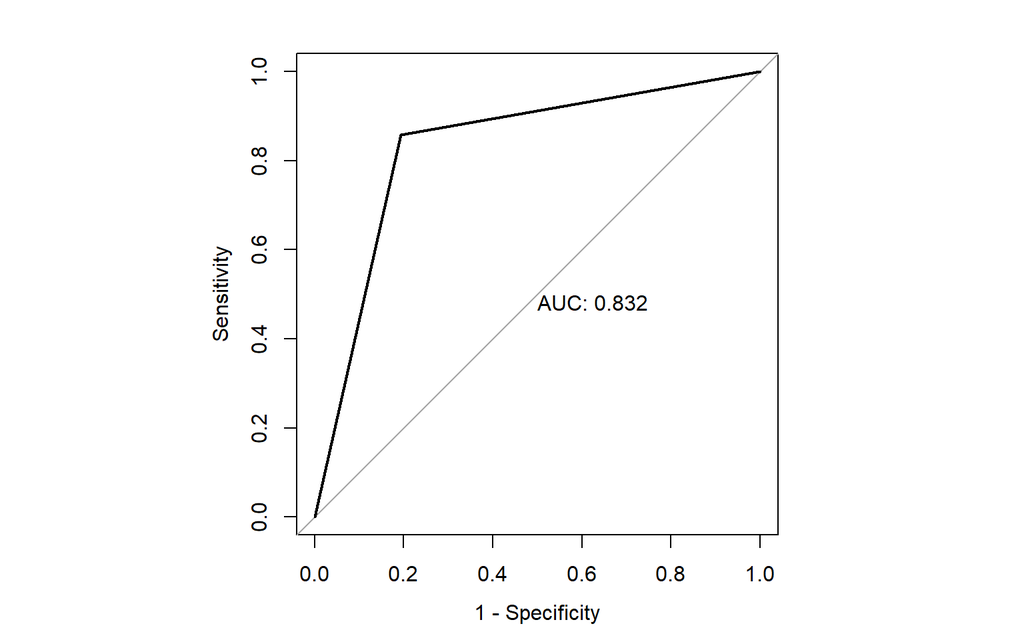

```
Call:
roc.default(response = test[["target"]], predictor = test[["baseline"]],     plot = TRUE, legacy.axes = TRUE, print.auc = TRUE)

Data: test[["baseline"]] in 62 controls (test[["target"]] 0) < 77 cases (test[["target"]] 1).
Area under the curve: 0.8318
```

```r
par(pty = "s")
roc(test[["target"]], test[["baseline"]], plot = TRUE, legacy.axes = TRUE, print.auc = TRUE)
```

```r
par(pty = "m")
```

#### Full Model

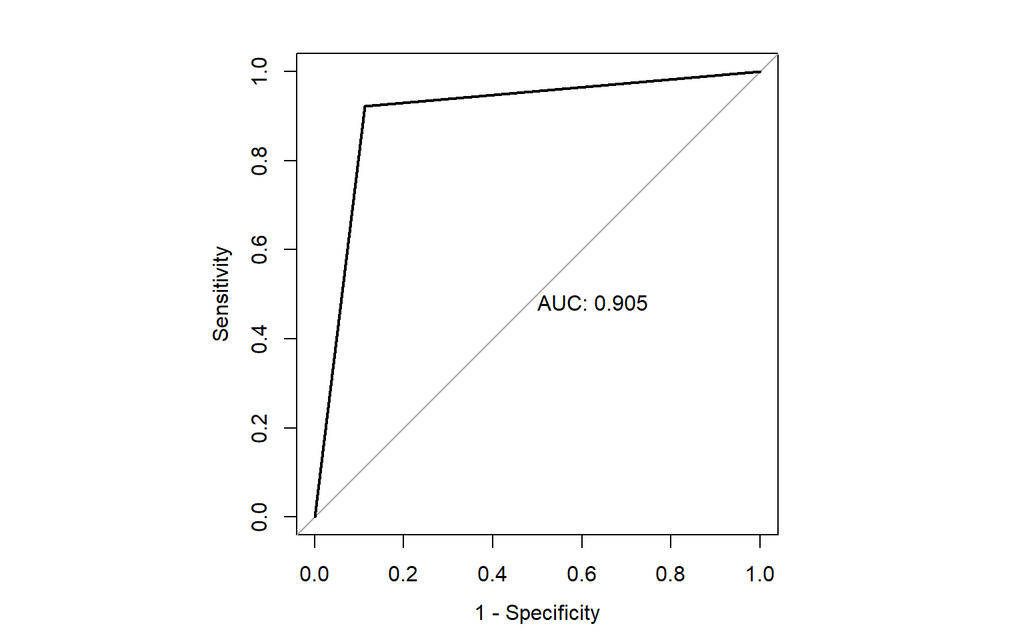

```
Call:
roc.default(response = test[["target"]], predictor = test[["fullmodel"]],     plot = TRUE, legacy.axes = TRUE, print.auc = TRUE)

Data: test[["fullmodel"]] in 62 controls (test[["target"]] 0) < 77 cases (test[["target"]] 1).
Area under the curve: 0.9046
```

```r
par(pty = "s")
roc(test[["target"]], test[["fullmodel"]], plot = TRUE, legacy.axes = TRUE, print.auc = TRUE)
```

```r
par(pty = "m")
```

#### Model1

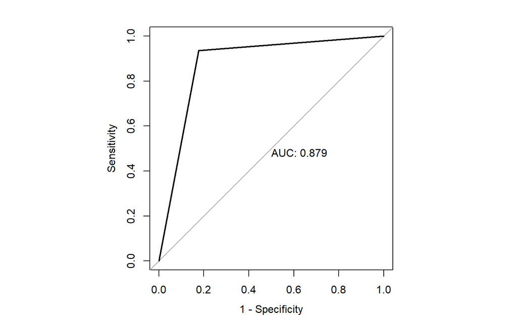

```
Call:
roc.default(response = test[["target"]], predictor = test[["model1"]],     plot = TRUE, legacy.axes = TRUE, print.auc = TRUE)

Data: test[["model1"]] in 62 controls (test[["target"]] 0) < 77 cases (test[["target"]] 1).
Area under the curve: 0.8788
```

```r
par(pty = "s")
roc(test[["target"]], test[["model1"]], plot = TRUE, legacy.axes = TRUE, print.auc = TRUE)
```

```r
par(pty = "m")
```

#### Density Model

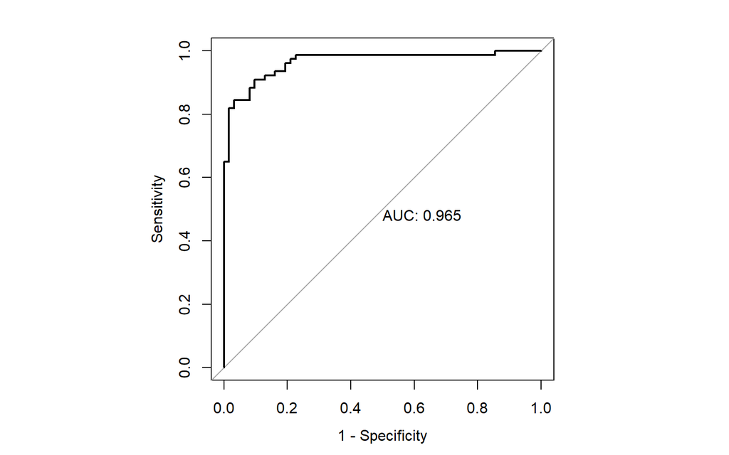

```
Call:
roc.default(response = test[["target"]], predictor = test[["density_models_yhat"]],     plot = TRUE, legacy.axes = TRUE, print.auc = TRUE)

Data: test[["density_models_yhat"]] in 62 controls (test[["target"]] 0) < 77 cases (test[["target"]] 1).
Area under the curve: 0.9652
```

```r
par(pty = "s")
roc(test[["target"]], test[["density_models_yhat"]], plot = TRUE, legacy.axes = TRUE, print.auc = TRUE)
```

```r
par(pty = "m")
```

Critical Thinking Group 3

2019-10-30